# Assignment 4.1 Hill, Zach

Zach Hill

05APR2019

# Desciptive Statistics

|  | exam | computer | lectures | numeracy | stats |
| --- | --- | --- | --- | --- | --- |
| median | 56.00 | 48.00 | 61.50 | 4.00 | 3.00 |
| mean | 56.16 | 46.23 | 58.60 | 4.61 | 3.22 |
| SE.mean | 1.63 | 0.85 | 1.83 | 0.21 | 0.12 |
| CI.mean.0.95 | 3.22 | 1.67 | 3.61 | 0.41 | 0.23 |
| var | 397.56 | 107.21 | 501.03 | 6.39 | 1.93 |
| std.dev | 19.94 | 10.35 | 22.38 | 2.53 | 1.39 |
| coef.var | 0.36 | 0.22 | 0.38 | 0.55 | 0.43 |

```
## exams$uni: George
##                exam computer lectures numeracy stats
## median        38.00    49.00    60.50     4.00  3.00
## mean          40.18    50.26    56.26     4.12  3.27
## SE.mean        1.78     1.14     3.36     0.29  0.21
## CI.mean.0.95   3.58     2.29     6.76     0.59  0.42
## var          158.48    65.09   565.14     4.27  1.97
## std.dev       12.59     8.07    23.77     2.07  1.40
## coef.var       0.31     0.16     0.42     0.50  0.43
## --------------------------------------------------------
## exams$uni: Jeff
##                exam computer lectures numeracy stats
## median        75.00    54.00     65.8     5.00  3.00
## mean          76.02    51.16     63.3     5.58  3.14
## SE.mean        1.44     1.20      2.7     0.43  0.20
## CI.mean.0.95   2.90     2.42      5.4     0.87  0.39
## var          104.14    72.34    359.8     9.43  1.92
## std.dev       10.21     8.51     19.0     3.07  1.39
## coef.var       0.13     0.17      0.3     0.55  0.44
## --------------------------------------------------------
## exams$uni: Tushmann
##                exam computer lectures numeracy stats
## median        49.00    36.00    60.50     4.00  3.00
## mean          52.28    37.26    56.26     4.12  3.27
## SE.mean        2.31     1.14     3.36     0.29  0.21
## CI.mean.0.95   4.65     2.29     6.76     0.59  0.42
## var          267.88    65.09   565.14     4.27  1.97
## std.dev       16.37     8.07    23.77     2.07  1.40
## coef.var       0.31     0.22     0.42     0.50  0.43
```

## Professor George

Professor George’s class tends towards lower scores in the exam and on numeracy as shown below.

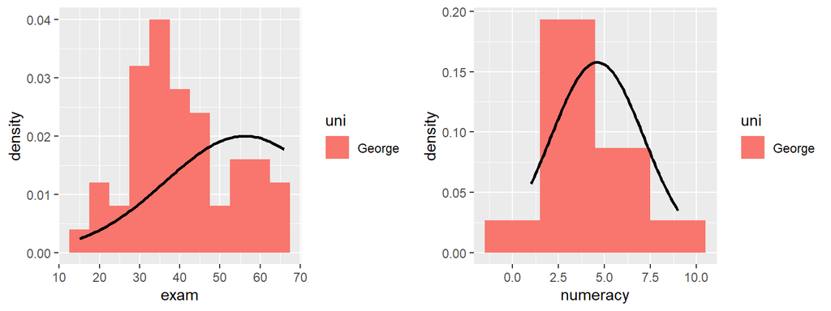

We can see that Professor Georges students’ median scores were below the mean, skewing the histograms right.

## Professor Jeff

Professor Jeff’s class tends towards higher scores in the exam and on computer assessments as shown below.

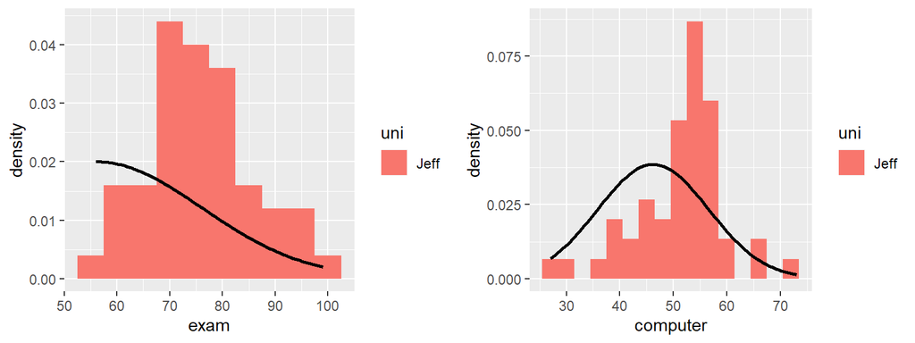

## Professor Tushmann

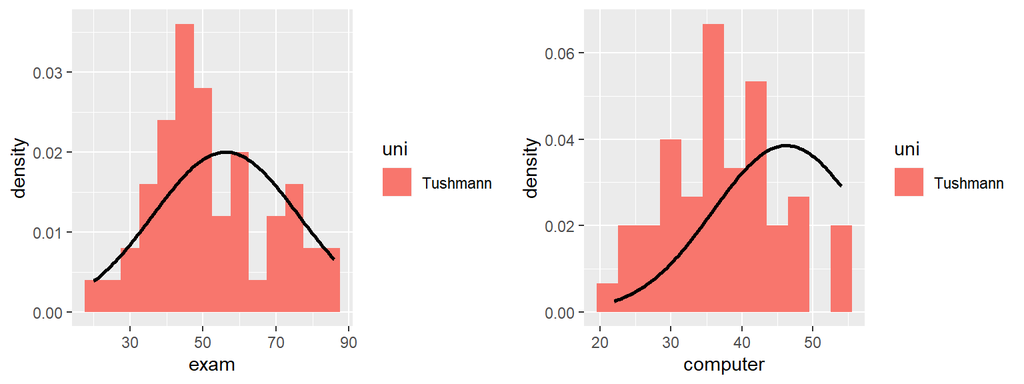

We can see here Professor Tushmann’s students’ median scores were below the overall mean skewing the histograms right.

## Shapiro-Wilk test

As we can see, most of the samples are not normally distributed as indicated by the sub-.05 p-value with the exception of the computer assessment

```
##
##  Shapiro-Wilk normality test
##
## data:  exams$exam
## W = 1, p-value = 0.006
```

```
##
##  Shapiro-Wilk normality test
##
## data:  exams$computer
## W = 1, p-value = 0.1
```

```
##
##  Shapiro-Wilk normality test
##
## data:  exams$lectures
## W = 1, p-value = 0.006
```

```
##
##  Shapiro-Wilk normality test
##
## data:  exams$numeracy
## W = 0.9, p-value = 5e-07
```

```
##
##  Shapiro-Wilk normality test
##
## data:  exams$stats
## W = 0.9, p-value = 3e-09
```

## Shapiro-Wilk test by professor

Most sample distributions appear normal with the exception of the stats and numeracy, and Professor Jeff’s computer assessments

Normalcy of computer assessments

```
## exams$uni: George
##
##  Shapiro-Wilk normality test
##
## data:  dd[x, ]
## W = 1, p-value = 0.5
##
## --------------------------------------------------------
## exams$uni: Jeff
##
##  Shapiro-Wilk normality test
##
## data:  dd[x, ]
## W = 0.9, p-value = 0.02
##
## --------------------------------------------------------
## exams$uni: Tushmann
##
##  Shapiro-Wilk normality test
##
## data:  dd[x, ]
## W = 1, p-value = 0.5
```

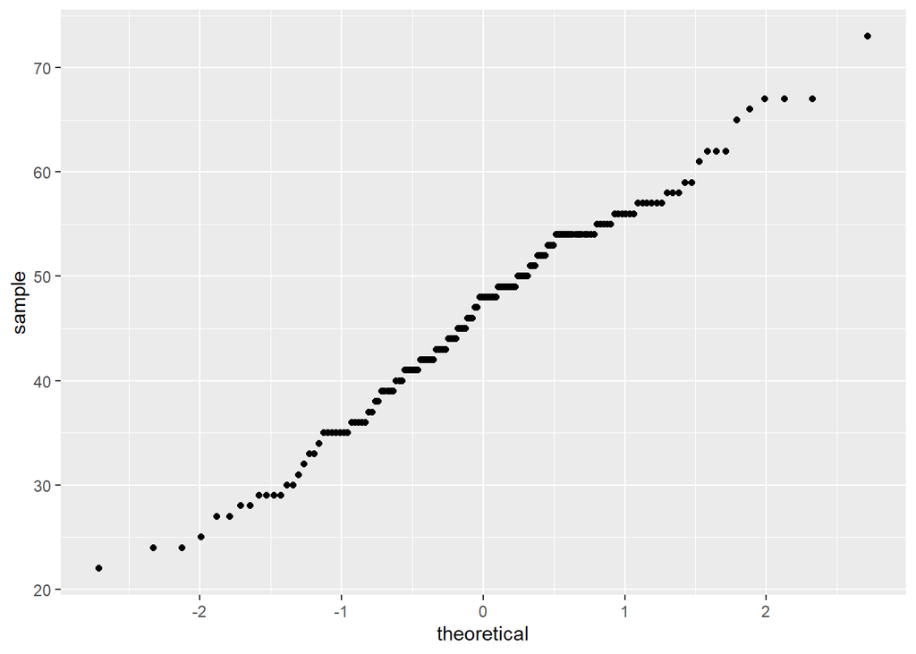

Professor Jeff’s students shows significant results with a .02 p-value

```
## exams$uni: George
##
##  Shapiro-Wilk normality test
##
## data:  dd[x, ]
## W = 0.9, p-value = 0.01
##
## --------------------------------------------------------
## exams$uni: Jeff
##
##  Shapiro-Wilk normality test
##
## data:  dd[x, ]
## W = 0.9, p-value = 0.007
##
## --------------------------------------------------------
## exams$uni: Tushmann
##
##  Shapiro-Wilk normality test
##
## data:  dd[x, ]
## W = 0.9, p-value = 0.01
```

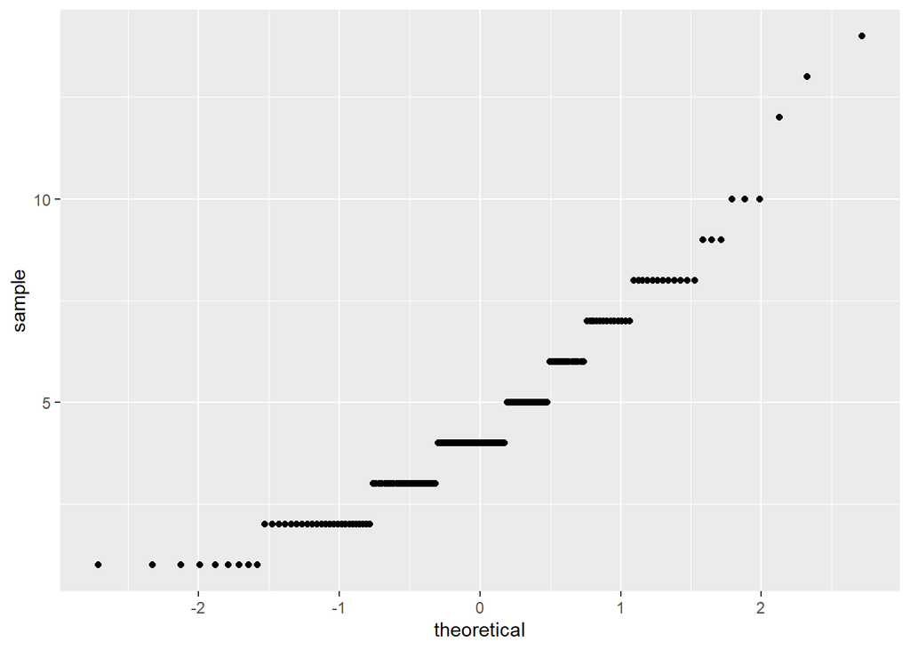

```
## exams$uni: George
##
##  Shapiro-Wilk normality test
##
## data:  dd[x, ]
## W = 0.9, p-value = 2e-04
##
## --------------------------------------------------------
## exams$uni: Jeff
##
##  Shapiro-Wilk normality test
##
## data:  dd[x, ]
## W = 0.9, p-value = 1e-04
##
## --------------------------------------------------------
## exams$uni: Tushmann
##
##  Shapiro-Wilk normality test
##
## data:  dd[x, ]
## W = 0.9, p-value = 2e-04
```

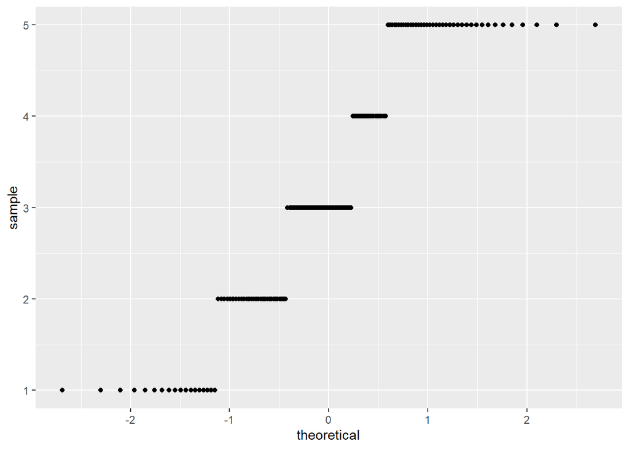